# Assignment_2_201_3.7.19

Sandra Fogg

3/8/2019

## 1. Patterns in Yield Over Time

#### Create a Finalized Graph of Yield Over Time for Each Grain

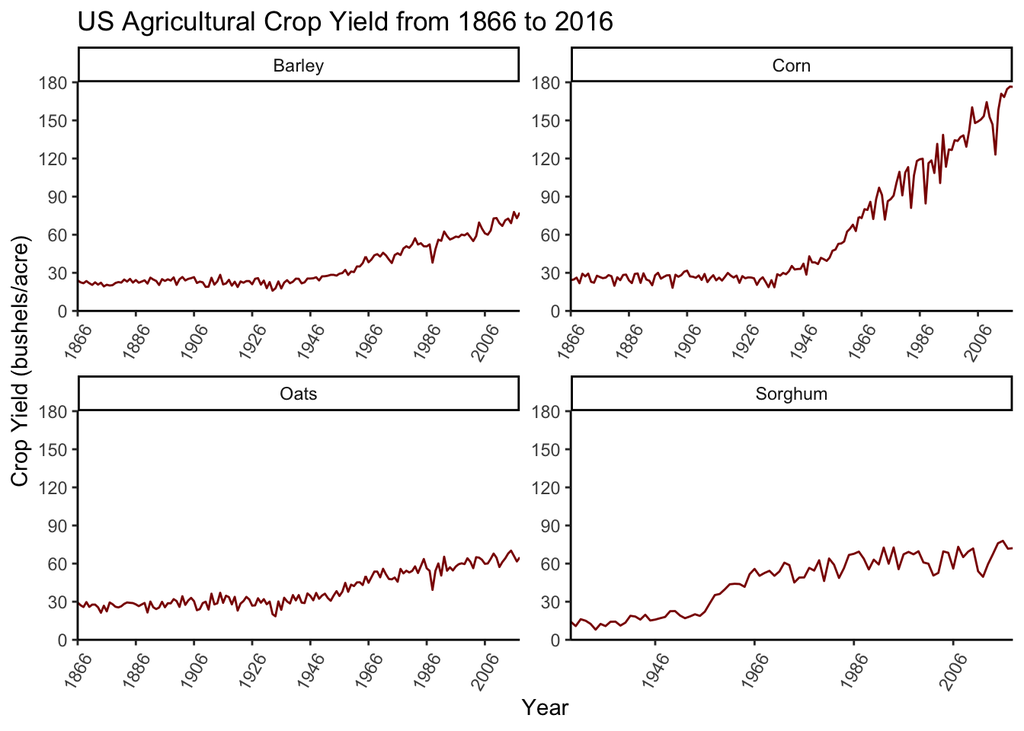

#### Describe which Statistical Models Characterize Trends

Corn is linear with a lower plateau, as exemplified by its sharp incline around the late 1940s, after relatively steady yields the previous 80 years.

Barley similiarly is a linear with a lower plateau model. Barley’s growth coincided with corn in the 1940s, however the magnitude of the growth was much less.

Oats also reflect the same model and trend. The boom of oat yields resembled barley, with a similar temporal and abundance trend.

Sorghum, however, is better described by the linear piecewise (PW) model. The data for sorghum is limited, and thus it is harder to describe a long-term trend than the other three. However, where the other three crops began to consistently have higher yields after the 1940s, sorghum appeared to level off after the initial increasing, suggesting a decreasing PW model.

## 2. Fertilizer Use

#### Create a Finalized Plot of Fertilizer Use vs. Time for Each Crop

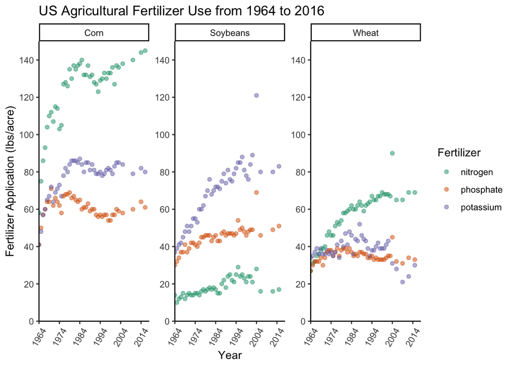

#### Describe Differences in Fertilizer Use for Each Crop

Corn and Wheat are primarily treated with Nitrogen fertilizer, although corn requires significantly more fertilizer than wheat, suggesting that Nitrogen is the limiting factor for plant growth. Corn’s extensive nutrient needs may be attributable to an inefficient uptake of Nitrogen. Soybeans are instead predominantly treated with Potassium, and are treated with very small amounts of Nitrogen. This is probably due to the nitrogen-fixing symbiotic organisms that live in the nodules of soybean plants, which enable them to acquire more Nitrogen from the surrounding soils. It is thus likely that Potassium is the limiting nutrient for soybean growth. While Phosphate fertilizer levels are a bit higher for corn, the three crops don’t appear to have a drastic difference in Phosphate application and require similar levels. Also it is important to note that the ratios of N:P:K vary a lot between the three crops. Corn and soybeans appear to have much larger ratios of the three nutrients, while the demand for nutrients is more evenly distributed for wheat.

#### Delve into Agricultural Literature

While Nitrogen is crucial to the growth of soybeans, about 50%-60% of the Nitrogen requirements are met by biological N<sub>2</sub> fixation in soils (Salvagiotti et al, 2008). Due to this availability, soybeans are restricted by other nutrients including Phosphate and Potassium. Potassium is the most limiting of these nutrients, requiring the highest amounts of fertilization for soybean plants. Soybeans remove 0.8 lbs/bushel of P<sub>2</sub>O<sub>5</sub>, which necessitates Phosphate fertilization. However, the crop removes almost twice as much Potassium, 1.4 lbs/bushel K<sub>2</sub>O, which is why Potassium must be added in the highest amounts to sustain crop yield (Staton, 2014).

Salvagiotti, F. et al. Nitrogen uptake, fixation and response to fertilizer N in soybeans: A review. Field Crops Res. 108, 1–13 (2008).

Staton, M. Phosphorus and potassium fertilizer recommendations for high-yielding, profitable soybeans. Michigan State University Extension. (2014).

## 3. Case Study: Corn and Fertilizer

#### Create a Finalized Plot of Corn Yield vs. PPA

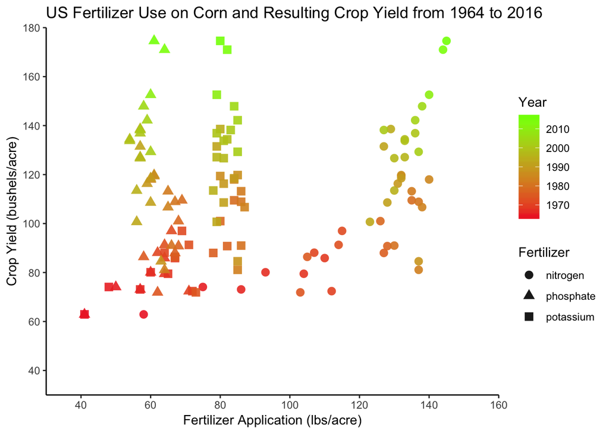